# Hypothesis Tests: **T tests**

The three main types of t test are:

- One-sample t test
- Paired t test
- Two-sample t test

The sections below consider each test separately, along with Python code for executing these tests.

## One-sample t test

The one-sample t statistic is:

|  |  | $t = \frac{ \overline{y} - \mu }{ s / \sqrt{n} }$ |  | (Equation 1) |
| --- | --- | --- | --- | --- |

where $\overline{y}$ is the sample mean, $\mu$ is the hypothesized mean, $s$ is the sample standard deviation and $n$ is the sample size.

A one sample t-test tests the following null hypothesis:

$H_0: \ \overline{y} = \mu$

### Example:

This example is a weight loss study from [Real Statistics Using Excel](http://www.real-statistics.com/students-t-distribution/one-sample-t-test/).

The data and results are:

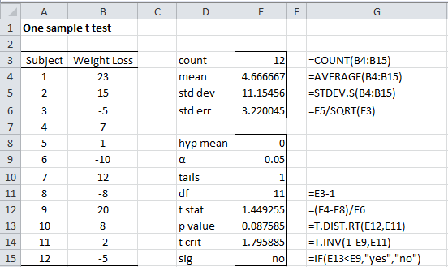

### Python:

This test can be conducted in Python using **scipy.stats.ttest_1samp** like this:

```python
import numpy as np
from scipy import stats
```

```python
y       = np.array([23, 15, -5, 7, 1, -10, 12, -8, 20, 8, -2, -5])  # data
mu      = 0    # hypothesized sample mean
results = stats.ttest_1samp(y, mu)

print(results)
```

```
Ttest_1sampResult(statistic=1.4492553137533357, pvalue=0.17516945558857122)
```

The t value and p value can be retreived like this:

```python
t = results.statistic
p = results.pvalue

print(t)
print(p)
```

```
1.4492553137533357
0.17516945558857122
```

Or like this:

```python
t,p = results

print(t)
print(p)
```

```
1.4492553137533357
0.17516945558857122
```

Note that the p value from **stats.ttest_1samp** does not match the p value from Real Statistics. This is because **stats.ttest_1samp** uses [two-tailed inference](https://en.wikipedia.org/wiki/One-_and_two-tailed_tests) and the Real Statistics example uses one-tailed inference.

To see agreement between the results, simply divide the **stats.ttest_1samp** p value result by two:

```python
print( p / 2 )
```

```
0.08758472779428561
```

The p value is larger than $\alpha$=0.05, so $H_0$ is not rejected.

## Paired t test

The paired t statistic is:

|  |  | $t = \frac{ \overline{d} }{ s / \sqrt{n} }$ |  | (Equation 2) |
| --- | --- | --- | --- | --- |

where:

$d_i = (y_1)_i - (y_2)_i$

A paired t-test tests the following null hypothesis:

$H_0: \ \overline{d} = 0$

### Example:

This example is from [WebStat at the University of New England](https://webstat.une.edu.au/unit_materials/c6_common_statistical_tests/example_paired_sample_t.html).

The data and results are:

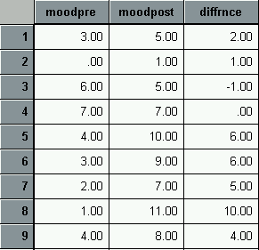

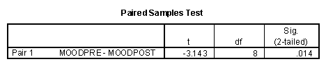

### Python:

This test can be conducted in Python using **scipy.stats.ttest_rel** like this:

```python
y_pre  = np.array( [3, 0, 6, 7, 4, 3, 2, 1, 4] )
y_post = np.array( [5, 1, 5, 7, 10, 9, 7, 11, 8] )

t,p    = stats.ttest_rel(y_pre, y_post)

print(t)
print(p)
```

```
-3.1428571428571423
0.013745824394788489
```

The p value is smaller than $\alpha$=0.05, so $H_0$ is rejected.

## Two-sample t test

The two-sample t statistic is:

|  |  | $t = \frac{ \overline{y}_1 - \overline{y}_2 }{ s_p \sqrt{ \frac{1}{n_1} + \frac{1}{n_2} } }$ |  | (Equation 3) |
| --- | --- | --- | --- | --- |

where

$s_p = \sqrt{ \frac{(n_1 - 1)s_1^2 + (n_2 - 1)s_2^2}{n_1 + n_2 - 2} }$

A two-sample t-test tests the following null hypothesis:

$H_0: \ \overline{y}_1 - \overline{y}_2 = 0$

### Example:

This example is from [qimacros.com](https://www.qimacros.com/hypothesis-testing/two-sample-t-test/).

The data and results are:

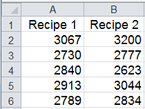

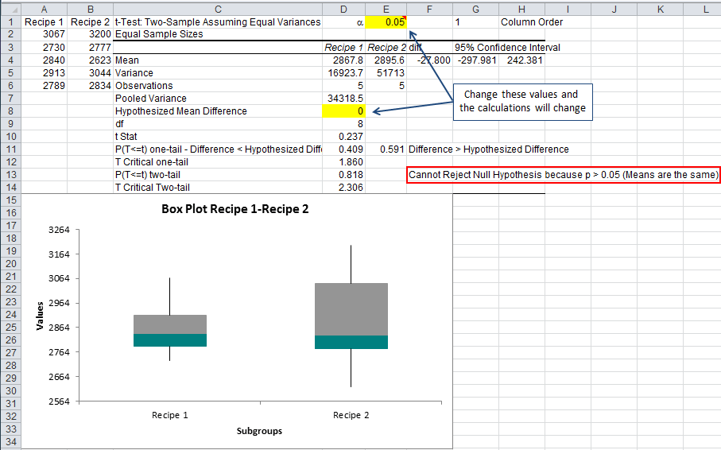

### Python:

This test can be conducted in Python using **scipy.stats.ttest_ind** like this:

```python
beginning = np.array( [3067, 2730, 2840, 2913, 2789] )
end       = np.array( [3200, 2777, 2623, 3044, 2834] )

t,p    = stats.ttest_ind(beginning, end)

print(t)
print(p)
```

```
-0.2372742730908139
0.8184074100386953
```

The p value is not less than $\alpha$=0.05, so $H_0$ is not rejected.